# Volcanoes

Laura Brugger

The following packages are required. Install using `install.packages` `ggplot2` `dplyr` `purrr`

## Visualizing Elevation of Volcanoes with Persistent Lava Lakes

First, let’s practice making a data frame. This data frame will include 7 volcanoes with persistent lava lakes plus the tallest volcano in the world, their location, their elevation, and their most recent known eruption.

```r
volcano <- c('Erta Ale', 'Ambrym', 'Mount Yasur', 'Mount Erebus', 'Kilauea', 'Nyiragongo', 'Masaya', 'Mauna Loa')
location <- c('Ethiopia','Vanuatu','Vanuatu','Antarctica','United States', 'Democratic Republic of the Congo','Nicaragua', 'United States')
elevation <- c(2011, 4377, 1184, 12448, 4091, 11385, 2083, 13678)
eruption <- c('2009', '2019', '2016', '2011', '2018', '2016', '2008', '1984')

volcData <- data.frame(volcano, location, elevation, eruption)
```

Create a bar chart to display the elevation of each volcano.

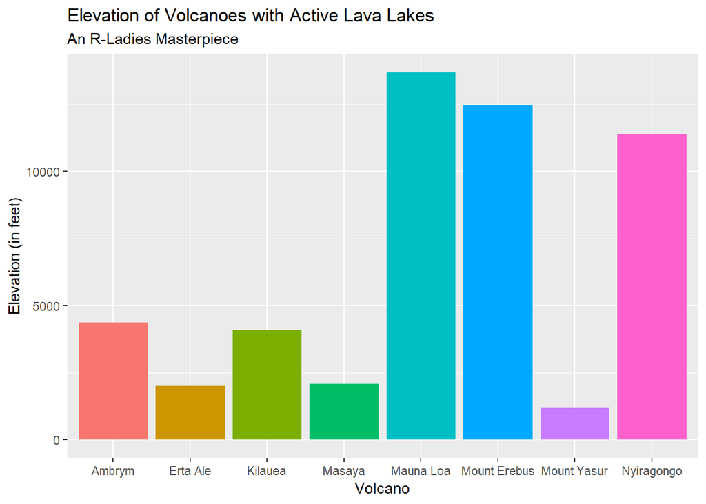

```r
library(ggplot2)
ggplot(data=volcData, aes(x=volcano, y=elevation, fill=volcano)) +
  geom_bar(stat="identity") +
  ggtitle("Elevation of Volcanoes with Active Lava Lakes", subtitle="An R-Ladies Masterpiece") +
  ylab("Elevation (in feet)") +
  xlab ("Volcano") +
  theme(legend.position = "none")
```

But Wait! Mauna Loa doesn’t have an active lava lake. Let’s get rid of it. Before we do that, this is a good time to save, add, commit, and push our work to GitHub. Go to your terminal and enter the following:

```r
#git -A
#git -a -m "add initial lava lake bar chart"
  #Remember, our commit message is a breadcrumb for us to remember why we made this commit
#git commit push origin
```

```r
library(dplyr)
volcData %>%
  filter (volcano != "Mauna Loa") -> lavaData
```

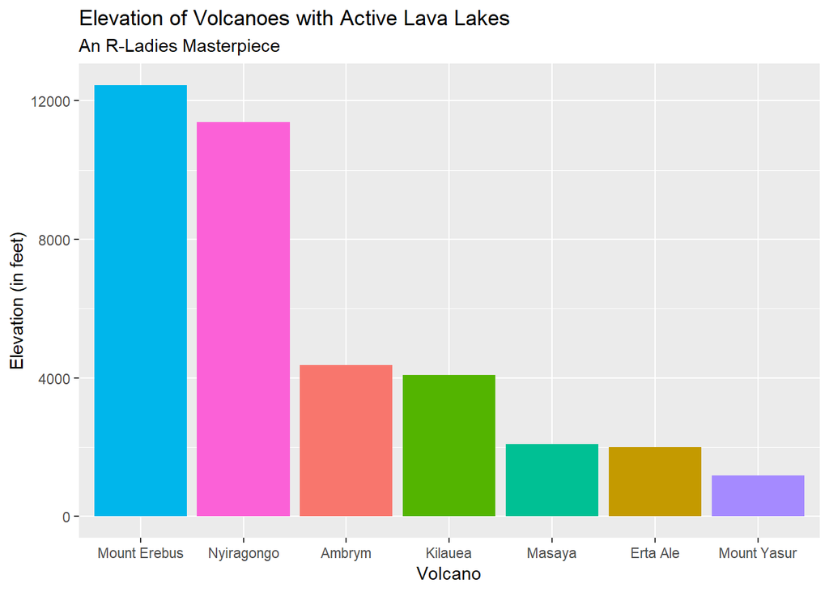

```r
ggplot(data=lavaData, aes(x= reorder (volcano, -elevation), y=elevation, fill=volcano)) +
  geom_bar(stat="identity") +
  ggtitle("Elevation of Volcanoes with Active Lava Lakes", subtitle="An R-Ladies Masterpiece") +
  ylab("Elevation (in feet)") +
  xlab ("Volcano") +
  theme(legend.position="none")
```

Save, add, commit, push!

```r
#git -A
#git -a -m "add revised lava lake bar chart that omits Mauna Loa"
#git commit push origin
```

Try it on your own and make a graph of the last known eruption fro each volcano.

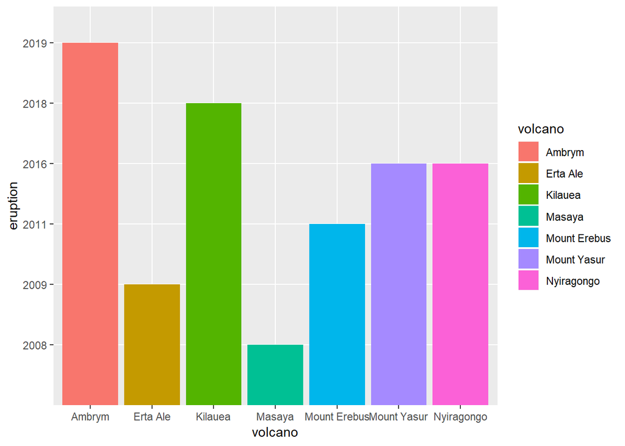

```r
ggplot(data=lavaData, aes(x=volcano, y=eruption, fill= volcano)) +
  geom_bar(stat = "identity")
```

```r
library(readxl)
eruptionData <- read_xlsx("volcano.xlsx")
```

Let’s get rid of Mauna Loa again.

```r
eruptionData %>%
  filter (volcano != "Mauna Loa") -> lavaEruptData
```

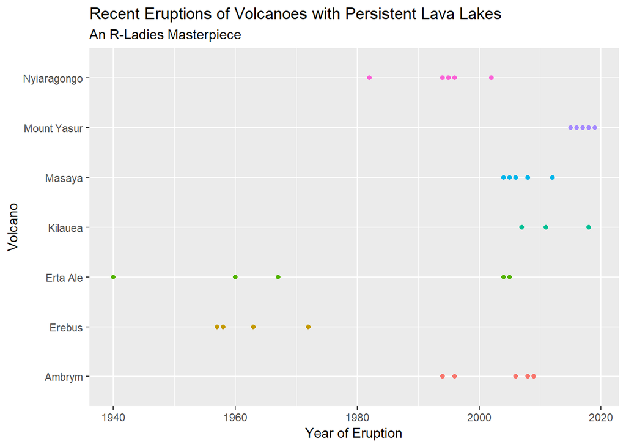

```r
ggplot(data=lavaEruptData, aes(y=volcano, x=eruption, color= volcano, position="dodge")) +
  geom_point() +
  ggtitle("Recent Eruptions of Volcanoes with Persistent Lava Lakes", subtitle="An R-Ladies Masterpiece") +
  ylab("Volcano") +
  xlab ("Year of Eruption") +
  theme(legend.position="none")
```

You know the drill: Save, add, commit, push!

```r
#git -A
#git -a -m "added new section to include recent eruption scatterplot"
#git commit push origin
```